# Part II - Prosper Loan Data Exploration

## by Donna Fedha Obong'o

## Dataset Overview

The dataset being explored is a loan dataset containing 113,937 loans(rows) and with 81 variables(columns),some of these variables are Borrower rate(Interest rate),term(how long the loan has been taken for), prosper score also known as the risk rating and more. It is important to note that each loan has a listing key which is a unique key for each listing, same value as the 'key' used in the listing object in the API.

## Investigation Overview

The relationship between the Borrower APR and Lender yield are positively correlated. This means that as the borrower rate increases then the lender yield also increases. It is important to note that the higher the prosper score the lower the lender yield and borrower APR. This can be seen in the plot for LenderYield vs BorrowerAPR vs ProsperScore.

## Borrower Rate and Borrower APR

According to [Investopedia](https://www.investopedia.com/ask/answers/100314/what-difference-between-interest-rate-and-annual-percentage-rate-apr.asp) interest rate is used when calculating the interest expense on your loan while APR includes not only the interest expense on the loan but also all fees and other costs involved in procuring the loan.  
In the **visualization** above,the visualizations are similar with a slight difference since the APR of a loan is higher than the loan’s interest rate because it considers multiple costs of borrowing.

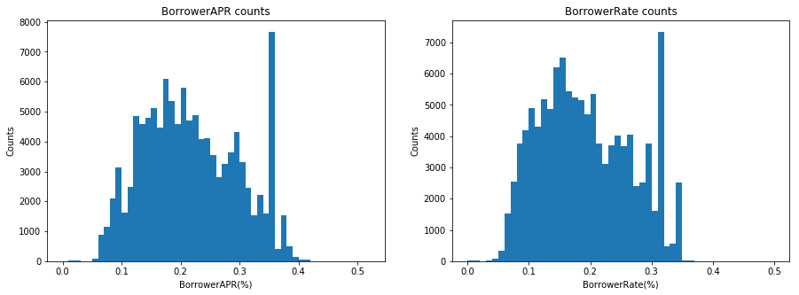

```python
plt.figure(figsize = [15, 5])

#since BorrowerAPR contained null values
Loans_sub = Loans[~Loans['BorrowerAPR'].isnull()]

#subplot for borrower annual percentage rate
plt.subplot(1,2,1)
bins= np.arange(0, Loans_sub['BorrowerAPR'].max()+0.01,0.01)
plt.hist(data=Loans_sub, x='BorrowerAPR',bins=bins)
plt.xlabel('BorrowerAPR(%)')
plt.ylabel('Counts')
plt.title('BorrowerAPR counts');

#subplot for borrower rate
plt.subplot(1,2,2)
bins= np.arange(0, Loans_sub['BorrowerRate'].max()+0.01,0.01)
plt.hist(data=Loans_sub, x='BorrowerRate',bins=bins)
plt.xlabel('BorrowerRate(%)')
plt.ylabel('Counts')
plt.title('BorrowerRate counts')
plt.show();
```

## Prosper score counts

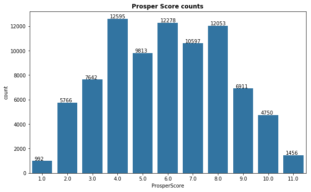

```python
#score ranges from 1-10, with 10 being the best, or lowest risk score.
plt.figure(figsize = [10,6])
base_color = sb.color_palette()[0]
ax= sb.countplot(data= Loans, x='ProsperScore',color= base_color)
for p in ax.patches:
        ax.annotate('{}'.format(p.get_height()), (p.get_x()+0.1, p.get_height()+50))
plt.title('Prosper Score counts', fontweight='bold')
plt.show();
```

## ProsperScore vs EstimatedEffective yield

The prosper score shows the risk factor, with 1 being the highest risk. A low prosper score means poor prospects from the borrower while a lower prosper score means better prospects. As shown below, the estimated effective yield is high on low prosper score and steadily decreases(as seen on the median line in the box plot) as it moves to higher prosper scores. This means that the lenders may charge different interest rates to borrowers with low prosper scores compared to borrowers with a high prosper score. A high risk borrower has a higher estimated effective yield.

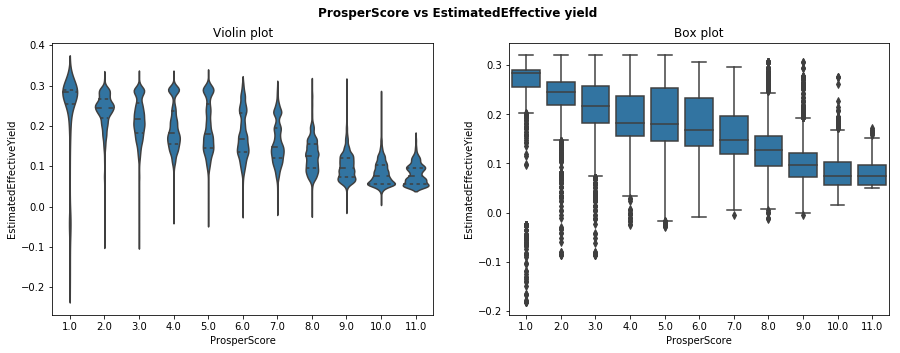

```python
plt.figure(figsize=[15,5]).suptitle('ProsperScore vs EstimatedEffective yield', fontweight='bold')

#violin plots
plt.subplot(1, 2, 1)
base_color = sb.color_palette()[0]
sb.violinplot(data = Loans, x='ProsperScore', y='EstimatedEffectiveYield', color=base_color, inner='quartile')
plt.title('Violin plot');

#boxplot
plt.subplot(1, 2, 2)
base_color = sb.color_palette()[0]
sb.boxplot(data = Loans, x='ProsperScore', y='EstimatedEffectiveYield', color=base_color)
plt.title('Box plot')
plt.show();
```

## Prosper score vs Lender yield

We can observe that the lower the risk rating(higher the prosper score), the lower the median for the lender yield , this may mean that lenders prefer borrowers with a low prosper score or rather a higher risk rating.

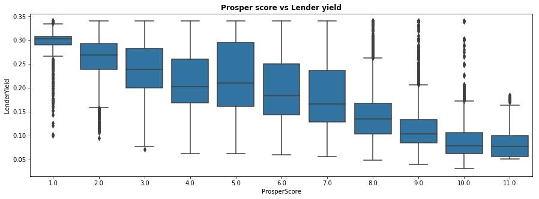

```python
plt.figure(figsize=[15,5])
sb.boxplot(data =Loans ,x='ProsperScore', y= 'LenderYield', color=base_color)
plt.title('Prosper score vs Lender yield', fontweight='bold')
plt.show();
```

## Regression plot for borrower rate and APR

There is a strong relationship between the two variables,the correlation is **positive**, this makes sense because the APR is the rate plus some extra costs. Thus as the borrower rate increases then the borrower APR also equally increases.

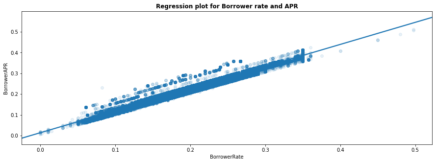

```python
#correlation between borrower APR and rate
plt.figure(figsize=[15,5])
sb.regplot(data=Loans, x='BorrowerRate', y= 'BorrowerAPR',scatter_kws={'alpha':0.1} )
plt.title('Regression plot for Borrower rate and APR', fontweight='bold')
plt.show();
```

## ProsperScore vs BorrowerRate

As the prosper score increases the borrower rate decreases in the median range,this shows that low risk borrowers have a low intererest rate compared to high risk borrowers. It is important to note that there are outliers above Q3 in prospers scores 8-10 which also means there are low risk borrowers with higher borrower rates and 1&2 has outliers below Q1. Overally, as prosper score improves, the interest rate decreases. This proves that lenders charge a lower rate to borrowers who have a good prosper score, thus the lower risk a borrower is the lower the interest rate.

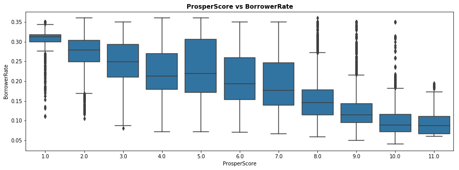

```python
#plot for borrower rate vs prosper score
plt.figure(figsize=[15,5])
sb.boxplot(data=Loans, x= 'ProsperScore', y='BorrowerRate',color=base_color)
plt.title('ProsperScore vs BorrowerRate', fontweight='bold')
plt.show();
```

## Heatmap

Prosper rating and prosper score are highly negatively correlated with borrower rate which means an increase in borrower rate results in a decrease in prosper rating/score and vice versa. Borrower rate and borrower APR are highly positively correlated, this is expected from the other observations previously done which means an increase in one leads to an increase in the other. The debt to income ratio does not correlate in any way with all the numeric variables shown below.

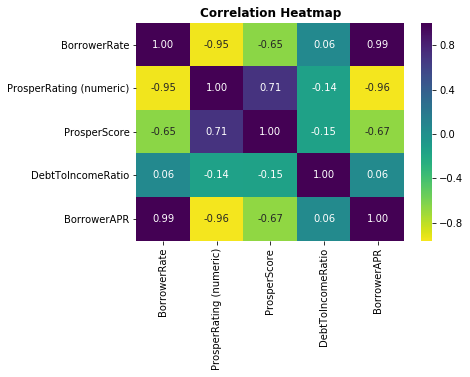

```python
#heatmap plot
sb.heatmap(Loans[['BorrowerRate', 'ProsperRating (numeric)', 'ProsperScore', 'DebtToIncomeRatio','BorrowerAPR']].corr(),
           annot = True, fmt = '.2f', cmap = 'viridis_r', center = 0)
plt.title('Correlation Heatmap', fontweight='bold')
plt.show();
```

## ProsperScore vs BorrowerRate vs LoanOriginalAmount

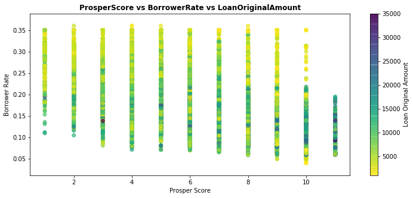

```python
plt.figure(figsize= [12,5])

#scatter plot
plt.scatter (data=Loans, x='ProsperScore', y='BorrowerRate',c = 'LoanOriginalAmount', cmap='viridis_r', alpha = 0.7)

#labels
plt.colorbar(label = 'Loan Original Amount')
plt.xlabel('Prosper Score')
plt.ylabel('Borrower Rate')
plt.title('ProsperScore vs BorrowerRate vs LoanOriginalAmount', fontweight='bold')
plt.show();
```

## LenderYield vs BorrowerAPR vs ProsperScore

We can see that the relationship between the Borrower APR and Lender yield are positively correlated. This means that as the borrower rate increases then the lender yield also increases. It is important to note that the higher the prosper score the lower the lender yield and borrower APR.

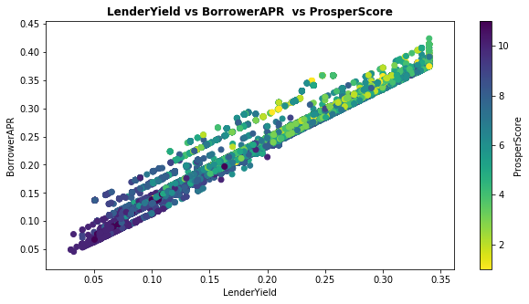

```python
# LenderYield vs Borrower APR  vs ProsperScore
plt.figure(figsize = [10, 5])

plt.scatter(data=Loans,x='LenderYield',y = 'BorrowerAPR',c='ProsperScore',cmap = 'viridis_r')

plt.colorbar(label = 'ProsperScore')
plt.title('LenderYield vs BorrowerAPR  vs ProsperScore', fontweight='bold')
plt.xlabel('LenderYield')
plt.ylabel('BorrowerAPR')
plt.show();
```

## Conclusion

From each exploration step, I have noted that there's a high negative correlation between the prosper score and the borrower rate & borrower APR.